# Fast and Sample-Accurate R-Peak Detectors Based on Visibility Graphs

Jonas Emrich, Taulant Koka, Sebastian Wirth, Michael Muma Technische Universität Darmstadt

2023-05-12

# Motivation

This Python package provides an implementation of visibility graph (VG) based approaches for detecting R-peaks in ECG signals. The utilized visibility graph transformation maps a given signal into a graph representation by expressing sampling locations as nodes and establishing edges between mutually visible samples. Subsequently, graph information is used to determine the R-peak positions.

In [1] and [2] benchmarking on several popular databases showed that the visibility graph based methods allow for sample-accurate R-peak detection and provide significantly superior performance compared to popular R-peak detectors.

# Installation

You can install the latest version of the ‘vg-beat-detectors’ package from the [Python Package Index (PyPI)](https://pypi.org/project/vg-beat-detectors/) by running:

```
pip install vg-beat-detectors
```

Additionally, the source code is available on [GitHub](https://github.com/JonasEmrich/vg-beat-detectors).

# Quick Start

This section illustrates, the basic usage of the ‘FastNVG’ and ‘FastWHVG’ detectors [1], which utilize the natural visibility graph (NVG) and weighted horizontal visibility graph (WHVG), respectively.

For both the ‘FastNVG’ and the ‘FastWHVG’ detectors, this package provides an identically named class that is initialized with the *sampling frequency* ‘fs’ of the given ECG signal. R-peaks can then be determined by applying the detectors `find_peaks(ecg)` method on the ECG signal.

This is exemplified in the following by means of the pseudo variables `fs` and `ecg`:

- FastNVG

```python
from vg_beat_detectors import FastNVG

detector = FastNVG(sampling_frequency=fs)
rpeaks = detector.find_peaks(ecg)
```

- FastWHVG

```python
from vg_beat_detectors import FastWHVG

detector = FastWHVG(sampling_frequency=fs)
rpeaks = detector.find_peaks(ecg)
```

## Complete Working Example

The next example demonstrates the application of the ‘FastNVG’ detector using real-world ECG data provided by the ‘scipy’ package. The utilization of the ‘FastWHVG’ is analogous.

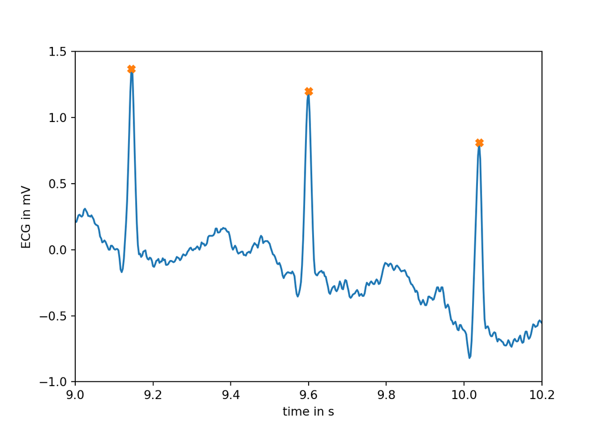

```python
# import the FastNVG detector
from vg_ecg_detectors import FastNVG

# import packages used in this example
import numpy as np
import matplotlib.pyplot as plt
from scipy.datasets import electrocardiogram

# generate some ECG signal
ecg = electrocardiogram() # sampling frequency of this excerpt is 360Hz
fs = 360
time = np.arange(ecg.size) / fs

# visibility graph R-peak detector
detector = FastNVG(sampling_frequency=fs)
R_peaks = detector.find_peaks(ecg)

# plot signal and detected peaks
plt.plot(time,ecg)
plt.plot(time[R_peaks],ecg[R_peaks],'X')
plt.xlabel("time in s")
plt.ylabel("ECG in mV")
plt.xlim(9, 10.2)
#> (9.0, 10.2)
plt.ylim(-1, 1.5)
#> (-1.0, 1.5)
plt.show()
```

# Advanced Usage

For advanced and experimental usage, the package provides the ‘VisGraphDetector’ base class, in which a number of parameters can be set, which will be briefly explained in the next paragraphs. For further understanding of the listed options and their influence on the algorithm, the interested user is referred to the papers [1] and [2].

The advanced usage follows the same structure as presented above:

```python
from vg_beat_detectors import VisGraphDetector

detector = VisGraphDetector(sampling_frequency=250,
                            graph_type='nvg',
                            edge_weight=None,
                            beta=0.55,
                            accelerated=False,
                            window_overlap=0.5,
                            window_length=2,
                            lowcut=4.0)

rpeaks = detector.find_peaks(ecg)
```

## Visibility graph types

The underlying visibility graph transformation can be selected with `graph_type`. The option ‘nvg’ results in the natural visibility graph and ‘hvg’ in the horizontal visibility graph.

## Weighted edges

The edges in the visibility graph representation can be constructed with a weighting factor. Therefore, the option `edge_weight` determines the metric for calculating the edge weight between two nodes (or samples).

Available weights are ‘distance’, ‘sq_distance’, ‘v_distance’, ‘abs_v_distance’, ‘h_distance’, ‘abs_h_distance’, ‘slope’, ‘abs_slope’, ‘angle’ and ‘abs_angle’ as well as None for no weighting.

For further explanation of each available weight, see the [documentation of the ‘ts2vg’ package](https://cbergillos.com/ts2vg/api/graph_options.html#weighted-graphs).

## Accelerated and non-accelerated processing

The acceleration technique proposed in [1] which reduces the input signal to only local maxima samples can be enabled or disabled by setting `accelerated` to `True` or `False`, respectively. The acceleration results in a run-time reduction by one order of magnitude while the detection accuracy remains comparable to that of the non-accelerated detector.

## Sparsity parameter $\beta$

As described in [1] and [2], the choice of the sparsity parameter $\beta \in [0, 1]$ depends on the used visibility graph transformation and edge weights. The parameter $\beta$ should be set appropriately to achieve a high detection performance. Sparsity parameter values for the NVG and WHVG were determined in numerical experiments in [1] and [2]. We highly recommend redetermining `beta` as described in [1] and [2], when changes have been made to the `graph_type` and `edge_weight` options.

## Adjusting segments

The input ECG signal is processed segment-wise using segments with a default length of $2 \sec$ and an overlap of $50\%$, i.e., `window_length=2` and `window_overlap=0.5`. As their name suggests, these parameters allow for adjustments of the window length and overlap.

## Setting highpass cutoff frequency

To change the lower cutoff frequency of the highpass filter that pre-processes the input ECG signal, the parameter `lowcut` can be modified. The default value is $4 \mathrm{Hz}$.

# References

[1]

Emrich, J., Koka, T., Wirth, S. and Muma, M. (2023). Accelerated Sample-Accurate R-Peak Detectors Based on Visibility Graphs.

[2]

Koka, T. and Muma, M. (2022). [Fast and Sample Accurate R-Peak Detection for Noisy ECG Using Visibility Graphs](https://doi.org/10.1109/EMBC48229.2022.9871266). 121–6.